# Major League Baseball **(MLB)** ⚾

The report has multiple sections and each has its own concluding remarks. Other than that it has **some comments within the sections**.

[figure not shown]

### ✨ Understanding the game:

Baseball, Game played with a bat and ball between two teams of nine players (or 10, if a designated hitter bats and runs for the pitcher). Baseball is played on a large field that has four bases laid out in a square, positioned like a diamond, whose outlines mark the course a runner must take to score.

The "**_** fielder" positions are called outer field positions and the rest are inner field.

# 1.Importing packages and loading the dataset

```python
import pandas as pd
import numpy as np
import matplotlib.pyplot as plt
%matplotlib inline
import seaborn as sns
import statsmodels
from scipy import stats
from scipy.stats import levene
import matplotlib.pyplot as plt
import statsmodels.api as sm
```

```python
df = pd.read_csv("mlb.csv")
pd.set_option('max_columns', None)
pd.set_option('max_rows', None)
df.head(5)
```

|  | salary | player_position | race | team_payroll | years_played | games_played | career_at_bats | career_runs | career_hits | career_doubles | career_triples | career_homeruns | career_runs_batted_in | career_batting_average | career_walks | career_strike_outs | career_stolen_bases | career_fielding_percent | white_percent_in_city | black_percent_in_city | hispanic_percent_in_city |
| --- | --- | --- | --- | --- | --- | --- | --- | --- | --- | --- | --- | --- | --- | --- | --- | --- | --- | --- | --- | --- | --- |
| 0 | 3375000 | shortstop | black | 38407380 | 8 | 918 | 3333 | 407 | 863 | 156 | 38 | 73 | 342 | 259 | 137 | 582 | 133 | 968 | 70.27797 | 18.84423 | 10.8778 |
| 1 | 3100000 | firstbase | white | 38407380 | 5 | 751 | 2807 | 370 | 840 | 148 | 18 | 46 | 355 | 299 | 341 | 228 | 41 | 994 | 70.27797 | 18.84423 | 10.8778 |
| 2 | 2900000 | thirdbase | white | 38407380 | 8 | 1056 | 3337 | 405 | 816 | 143 | 18 | 107 | 421 | 245 | 306 | 653 | 15 | 971 | 70.27797 | 18.84423 | 10.8778 |
| 3 | 1650000 | outfield | black | 38407380 | 12 | 1196 | 3603 | 437 | 928 | 19 | 16 | 124 | 541 | 258 | 316 | 725 | 32 | 977 | 70.27797 | 18.84423 | 10.8778 |
| 4 | 700000 | outfield | black | 38407380 | 17 | 2032 | 7489 | 1136 | 2145 | 270 | 142 | 40 | 574 | 286 | 416 | 1098 | 660 | 987 | 70.27797 | 18.84423 | 10.8778 |

```python
df.columns
```

```
Index(['salary', 'player_position', 'race', 'team_payroll', 'years_played',
       'games_played', 'career_at_bats', 'career_runs', 'career_hits',
       'career_doubles', 'career_triples', 'career_homeruns',
       'career_runs_batted_in', 'career_batting_average', 'career_walks',
       'career_strike_outs', 'career_stolen_bases', 'career_fielding_percent',
       'white_percent_in_city', 'black_percent_in_city',
       'hispanic_percent_in_city'],
      dtype='object')
```

# 2.Descriptive statistics 📊

```python
df.info()
```

```
<class 'pandas.core.frame.DataFrame'>
RangeIndex: 352 entries, 0 to 351
Data columns (total 21 columns):
 #   Column                    Non-Null Count  Dtype
---  ------                    --------------  -----
 0   salary                    352 non-null    int64
 1   player_position           352 non-null    object
 2   race                      352 non-null    object
 3   team_payroll              352 non-null    int64
 4   years_played              352 non-null    int64
 5   games_played              352 non-null    int64
 6   career_at_bats            352 non-null    int64
 7   career_runs               352 non-null    int64
 8   career_hits               352 non-null    int64
 9   career_doubles            352 non-null    int64
 10  career_triples            352 non-null    int64
 11  career_homeruns           352 non-null    int64
 12  career_runs_batted_in     352 non-null    int64
 13  career_batting_average    352 non-null    int64
 14  career_walks              352 non-null    int64
 15  career_strike_outs        352 non-null    int64
 16  career_stolen_bases       352 non-null    int64
 17  career_fielding_percent   352 non-null    int64
 18  white_percent_in_city     329 non-null    float64
 19  black_percent_in_city     329 non-null    float64
 20  hispanic_percent_in_city  329 non-null    float64
dtypes: float64(3), int64(16), object(2)
memory usage: 57.9+ KB
```

```python
df.describe()
```

|  | salary | team_payroll | years_played | games_played | career_at_bats | career_runs | career_hits | career_doubles | career_triples | career_homeruns | career_runs_batted_in | career_batting_average | career_walks | career_strike_outs | career_stolen_bases | career_fielding_percent | white_percent_in_city | black_percent_in_city | hispanic_percent_in_city |
| --- | --- | --- | --- | --- | --- | --- | --- | --- | --- | --- | --- | --- | --- | --- | --- | --- | --- | --- | --- |
| count | 3.520000e+02 | 3.520000e+02 | 352.000000 | 352.000000 | 352.000000 | 352.000000 | 352.000000 | 352.000000 | 352.000000 | 352.000000 | 352.000000 | 352.000000 | 352.000000 | 352.000000 | 352.000000 | 352.000000 | 329.000000 | 329.000000 | 329.000000 |
| mean | 1.331514e+06 | 3.077320e+07 | 6.309659 | 645.423295 | 2155.704545 | 288.170455 | 580.889205 | 103.267045 | 16.590909 | 54.531250 | 263.122159 | 258.900568 | 210.926136 | 338.681818 | 65.096591 | 976.474432 | 72.638240 | 16.541950 | 10.819810 |
| std | 1.383952e+06 | 8.725344e+06 | 3.873810 | 536.499990 | 2013.393716 | 298.500277 | 571.632472 | 103.831374 | 21.395948 | 73.369759 | 281.741692 | 38.443636 | 227.191851 | 323.886980 | 112.548093 | 19.751430 | 15.249897 | 13.688558 | 9.402261 |
| min | 1.090000e+05 | 8.854000e+06 | 1.000000 | 7.000000 | 7.000000 | 1.000000 | 1.000000 | 0.000000 | 0.000000 | 0.000000 | 1.000000 | 111.000000 | 0.000000 | 0.000000 | 0.000000 | 800.000000 | 20.296300 | 3.741786 | 0.540870 |
| 25% | 2.527000e+05 | 2.455733e+07 | 3.000000 | 230.000000 | 631.500000 | 73.000000 | 163.000000 | 26.000000 | 3.000000 | 8.000000 | 59.750000 | 245.000000 | 49.750000 | 101.000000 | 4.750000 | 969.000000 | 67.668960 | 8.007545 | 1.962080 |
| 50% | 6.750000e+05 | 3.413650e+07 | 6.000000 | 518.500000 | 1583.000000 | 190.500000 | 416.000000 | 70.000000 | 9.000000 | 26.000000 | 172.000000 | 259.000000 | 137.000000 | 235.500000 | 24.500000 | 980.500000 | 74.619650 | 14.453980 | 10.877800 |
| 75% | 2.250000e+06 | 3.779200e+07 | 9.000000 | 930.000000 | 3026.000000 | 405.500000 | 817.250000 | 146.250000 | 23.000000 | 70.000000 | 358.000000 | 275.000000 | 304.250000 | 474.000000 | 75.000000 | 988.000000 | 82.948860 | 18.755630 | 16.330650 |
| max | 6.200000e+06 | 4.286600e+07 | 20.000000 | 2729.000000 | 10554.000000 | 1570.000000 | 3025.000000 | 634.000000 | 142.000000 | 432.000000 | 1710.000000 | 625.000000 | 1286.000000 | 1891.000000 | 1042.000000 | 1000.000000 | 94.696270 | 73.960030 | 31.037500 |

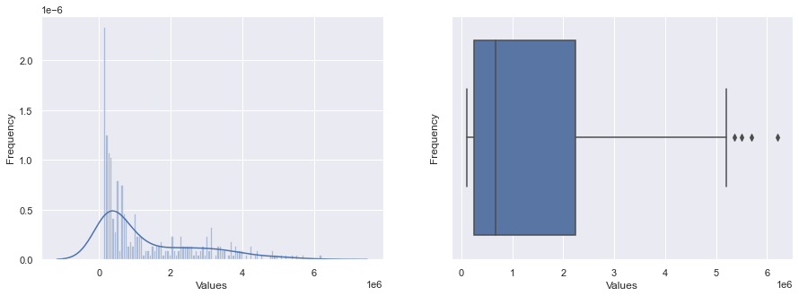

```python
fig = plt.figure(figsize=(15,5))

plt.subplot(1,2,1)
hist = sns.distplot(df['salary'],bins=100)
hist.set(xlabel = 'Values',ylabel ="Frequency")

plt.subplot(1,2,2)
box = sns.boxplot(df['salary'])
box.set(xlabel = 'Values',ylabel ="Frequency")

plt.show()
```

```python
print("Skewness: %f" % df['salary'].skew())
print("Kurtosis: %f" % df['salary'].kurt())
print("Mean: %f" % df['salary'].mean())
print("Median: %f" % df['salary'].median())
```

```
Skewness: 1.211830
Kurtosis: 0.525475
Mean: 1331514.463068
Median: 675000.000000
```

```python
df.describe(include=[np.object])
```

|  | player_position | race |
| --- | --- | --- |
| count | 352 | 352 |
| unique | 6 | 3 |
| top | outfield | white |
| freq | 136 | 180 |

```python
df['player_position'].value_counts()
```

```
outfield      136
catcher        52
shortstop      49
firstbase      45
secondbase     36
thirdbase      34
Name: player_position, dtype: int64
```

```python
df['race'].unique()
```

```
array(['black', 'white', 'hispanic'], dtype=object)
```

```python
df['race'].value_counts()
```

```
white       180
black       108
hispanic     64
Name: race, dtype: int64
```

### Descriptive statistics summary 📝:

#### ✨ Overview:

The given data set has 352 entries. Out of the 21 variables, 19 of them are neumerical variables and 2 (race & position) are categrorical.

#### ✨ Takeways:

1. Intuitively Salary would depend on the performance of the player and not the other way around. And most variables are about the performance of the individual players. We will run our regression on this dependent variable later on.
2. Data seems skewed so we might need to do log transformations before conducting statistical tests
3. The distribution of data over the catagorical variables are uneven. We have to be careful while maing comparative studies.
4. There are some missing data we will handle them in the next section.

# 3. Missing data:

```python
pd.DataFrame(df.isnull().sum(),columns=['Number of missing values'])
```

|  | Number of missing values |
| --- | --- |
| salary | 0 |
| player_position | 0 |
| race | 0 |
| team_payroll | 0 |
| years_played | 0 |
| games_played | 0 |
| career_at_bats | 0 |
| career_runs | 0 |
| career_hits | 0 |
| career_doubles | 0 |
| career_triples | 0 |
| career_homeruns | 0 |
| career_runs_batted_in | 0 |
| career_batting_average | 0 |
| career_walks | 0 |
| career_strike_outs | 0 |
| career_stolen_bases | 0 |
| career_fielding_percent | 0 |
| white_percent_in_city | 23 |
| black_percent_in_city | 23 |
| hispanic_percent_in_city | 23 |

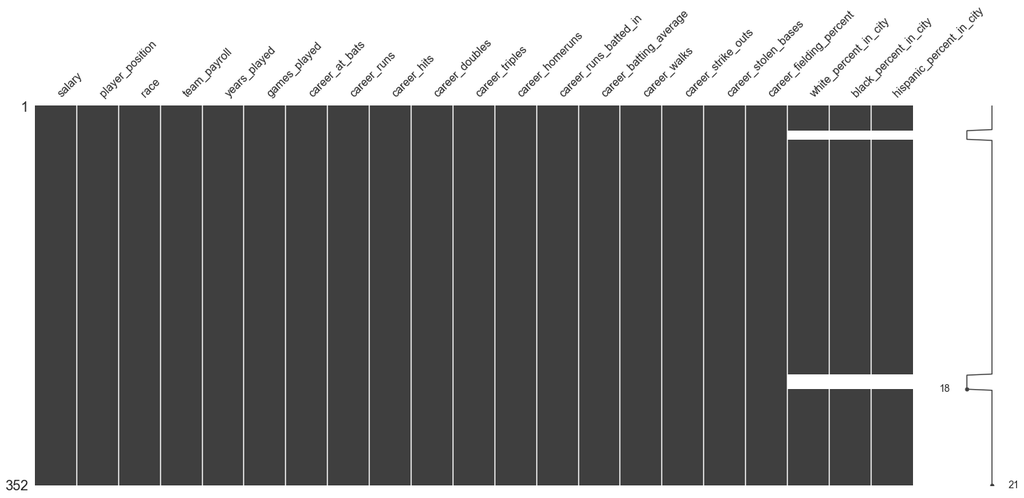

```python
import missingno as msno
msno.matrix(df)
```

#### The missing data are from the "*__* percent in city" columns, and it looks like chunks of the data are missing together. We have to decide how we want to deal with these missing values after farther analysis.

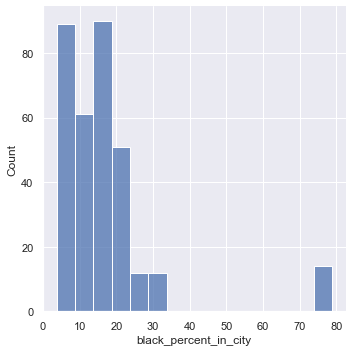

```python
sns.displot(df, x="black_percent_in_city",multiple="dodge",binwidth=5, common_norm=False)
```

As per descriptive statistics the mean of "black_percent_in_city" is 16.541950 but the histogram shows outliers, which might influence our imputation. So we will take the median for imputing the missing value.

```python
df['black_percent_in_city'].fillna(value = df['black_percent_in_city'].median(), inplace=True)
```

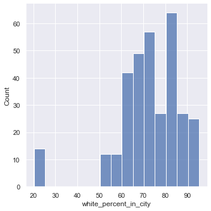

```python
sns.displot(df, x="white_percent_in_city",multiple="dodge",binwidth=5, common_norm=False)
```

```python
df['white_percent_in_city'].fillna(df['white_percent_in_city'].median(), inplace=True)
```

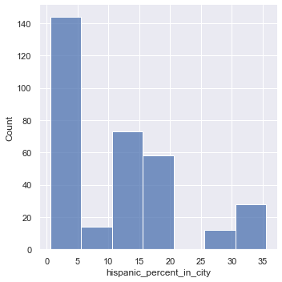

```python
sns.displot(df, x="hispanic_percent_in_city",multiple="dodge",binwidth=5, common_norm=False)
```

```python
df['hispanic_percent_in_city'].fillna(value = df['hispanic_percent_in_city'].mean(), inplace=True)
```

```python
pd.DataFrame(df.isnull().sum(),columns=['Number of missing values'])
```

|  | Number of missing values |
| --- | --- |
| salary | 0 |
| player_position | 0 |
| race | 0 |
| team_payroll | 0 |
| years_played | 0 |
| games_played | 0 |
| career_at_bats | 0 |
| career_runs | 0 |
| career_hits | 0 |
| career_doubles | 0 |
| career_triples | 0 |
| career_homeruns | 0 |
| career_runs_batted_in | 0 |
| career_batting_average | 0 |
| career_walks | 0 |
| career_strike_outs | 0 |
| career_stolen_bases | 0 |
| career_fielding_percent | 0 |
| white_percent_in_city | 0 |
| black_percent_in_city | 0 |
| hispanic_percent_in_city | 0 |

We imputed the missiong values with relevant reasoning in the above cells.

# 4. Exploratory data analysis through visualizations 🔍

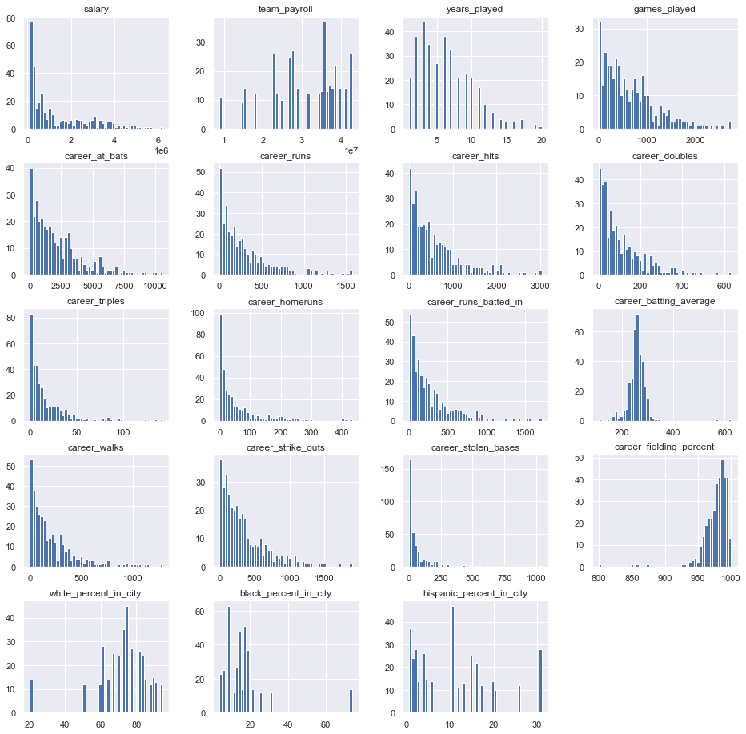

```python
dummy = df.hist(bins=50, figsize=(16,16))
```

A lot of the values look right skewed, they need to be **log transformed** for statistical inferences

#### Analysing the catagorical variables:

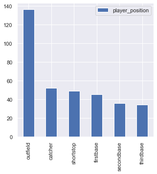

```python
dfposition = pd.DataFrame(df['player_position'].value_counts())
plot = dfposition.plot.bar(y='player_position',figsize=(5,5))
```

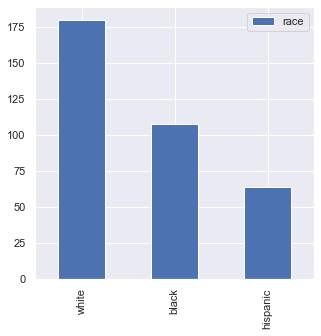

```python
dfrace = pd.DataFrame(df['race'].value_counts())
plot = dfrace.plot.bar(y='race',figsize=(5,5))
```

### ✨ Why we need to normalize?

Since we have unequal numbers of observations, comparing their distributions in terms of counts may not be ideal. One solution is to normalize the counts using the stat parameter. the normalization is applied to the entire distribution, so this simply rescales the height of the bars. By setting common_norm=False, each subset will be normalized independently.

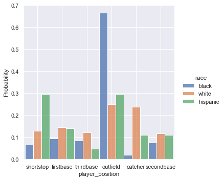

```python
sns.displot(df, x="player_position", hue="race",multiple="dodge",binwidth=1000000, stat = 'probability', common_norm=False)
plt.margins(x=.01)
```

#### The y-axis shows the probability of each race in the respective positions, i.e., the sum of values all the fielding positions of the black race(blue bars) will be 1.00.

### ✨ General statements:

##### Secondary research shows that shortstop is an "action-packed" position and the most agile players are placed here. If we assume the stereotype that hispanics and whites are agile, the data stays coherent with the research statement.

##### Catchers position is assumed to be the hardest, the whites dominate this position among other races

##### The outfield positions are generally considered to be easier to play than the infield positions and tend to be dominated by good hitters. And as the data shows, the outfield is dominated by the blacks, but other races are there as well.

#### 🤔 This begs the question: Are all outfields good hitters? Is this statement statistically significant?

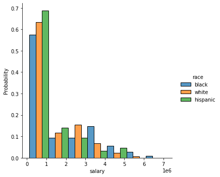

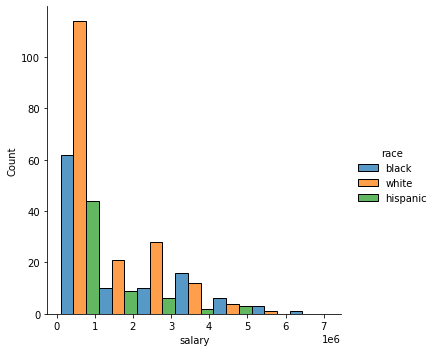

```python
sns.displot(df, x="salary", hue="race",multiple="dodge",binwidth=1000000, stat = 'probability', common_norm=False)
sns.displot(df, x="salary", hue="race",multiple="dodge",binwidth=1000000)
```

### ✨ Explanation of the 2 charts

The second histogram shows that count of white players in the "<2x10^6 range" is more compared to others, the first graph shows its comparitively more probable for Hispanic players to be in the 0-2x10^6 salary range.

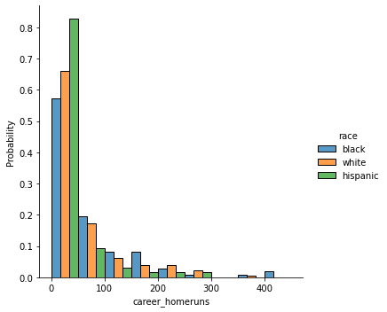

```python
sns.displot(df, x="career_homeruns", hue="race",multiple="dodge",binwidth=50,stat='probability', common_norm=False)
```

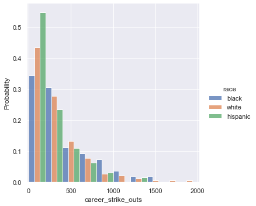

```python
sns.displot(df, x="career_strike_outs", hue="race",multiple="dodge",binwidth=200,stat='probability', common_norm=False)
plt.margins(x=.01)
```

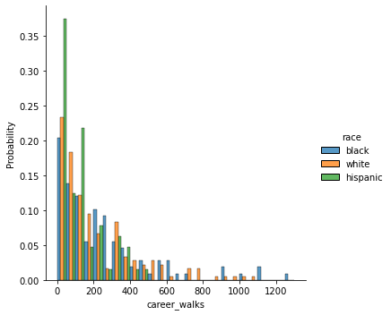

```python
sns.displot(df, x="career_walks", hue="race",multiple="dodge",binwidth=50,stat='probability', common_norm=False)
```

#### Extending on the hispanics 🌮:

Hispanics are comparitively underperforming but they are still prevelant in the sport. Presumeably because of 2 reasons:

A. Agility: Hispanics are comparitively shorter and they outperform others with their positioning and faster reflexes in important positions of the field. (Probably thats why they were more common in the "shortstop position" which is known to be one of the hardest positions to play)

B. Exposure: The alternative sports in America are basketball and football, both of which require genetically gifted physique to have an upperhand. So its safe to assume hispanics are comfortable choosing a sport where they know they will be able to contibute substantially.

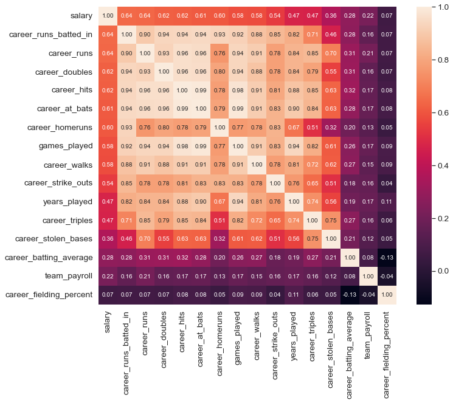

```python
df_corr = df.drop(['white_percent_in_city','black_percent_in_city','hispanic_percent_in_city'], axis=1)
k=16
corrmat = df_corr.corr()
cols = corrmat.nlargest(k, 'salary')['salary'].index
cm = np.corrcoef(df_corr[cols].values.T)
sns.set(font_scale=1.25)
f, ax = plt.subplots(figsize=(12, 9))
hm = sns.heatmap(cm, cbar=True, annot=True, square=True, fmt='.2f', annot_kws={'size': 10}, yticklabels=cols.values, xticklabels=cols.values)
plt.show()
```

### Most higly correlated to salary are 'career_at_bats', 'career_runs', 'career_hits', 'career_doubles', 'career_homeruns','career_runs_batted_in'.

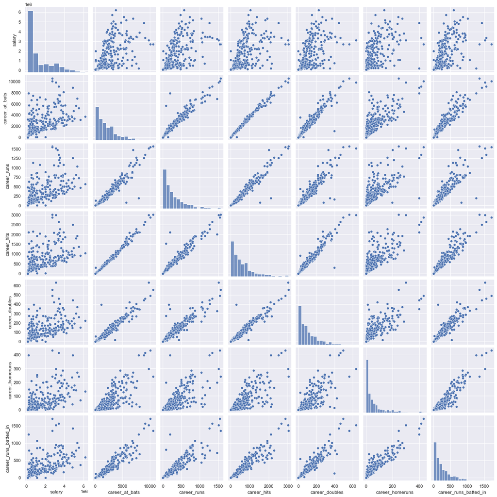

```python
sns.set()
cols = ['salary','career_at_bats', 'career_runs', 'career_hits',
       'career_doubles', 'career_homeruns',
       'career_runs_batted_in']
sns.pairplot(df[cols], diag_kind="hist", height = 2.5)
plt.show();
```

# 5. Delving deeper into the catagorical variables

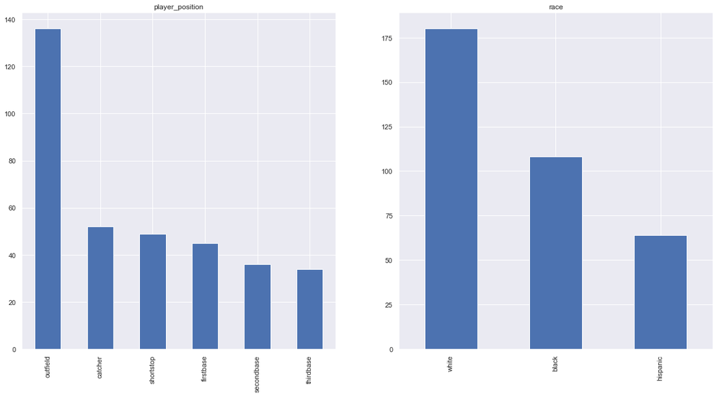

```python
categorical = df.select_dtypes(include=['object']).columns
fig, ax = plt.subplots(1, len(categorical), figsize=(20, 10))
for i, categorical in enumerate(df[categorical]):
 df[categorical].value_counts().plot(kind="bar", ax=ax[i]).set_title(categorical)
```

```python
crosstb1 = pd.crosstab(index=df['race'], columns=df['player_position'])
crosstb1
```

| player_position race | catcher | firstbase | outfield | secondbase | shortstop | thirdbase |
| --- | --- | --- | --- | --- | --- | --- |
| black | 2 | 10 | 72 | 8 | 7 | 9 |
| hispanic | 7 | 9 | 19 | 7 | 19 | 3 |
| white | 43 | 26 | 45 | 21 | 23 | 22 |

We will conduct our test with crosstb1 because chi-square doesnt assume normalized data.

## 🧪 Chi-squared testing:

**Null hypothesis:** There is no relation between the race and player position.

**Alternate hypothesis:** There is significant relation between the race and player position.

**Significance level (α):** 0.05

```python
chi2, p_val, dof, expected =stats.chi2_contingency(crosstb1)
print(f'p_value: {p_val}')
print(f'chi2: {chi2}')
print(f'dof: {dof}')
print(f'expected: {expected}')
```

```
p_value: 2.2934333235364454e-12
chi2: 76.62632929810103
dof: 10
expected: [[15.95454545 13.80681818 41.72727273 11.04545455 15.03409091 10.43181818]
 [ 9.45454545  8.18181818 24.72727273  6.54545455  8.90909091  6.18181818]
 [26.59090909 23.01136364 69.54545455 18.40909091 25.05681818 17.38636364]]
```

### Comments on Chi-squared

P value is below .05 so we can reject the null. There is significant relationship between the 2 catagorical variables.

Expected values differ from observed values:

#### Takeaway:

Whites over represent the Catchers position

Blacks over represent the Outfielders position

Hispanics over represent the Shortstoppers position

# 6.Analysing subgroups within the dataset

```python
pd.DataFrame(df.groupby(["player_position","race"]).mean())
```

| player_position | race | salary | team_payroll | years_played | games_played | career_at_bats | career_runs | career_hits | career_doubles | career_triples | career_homeruns | career_runs_batted_in | career_batting_average | career_walks | career_strike_outs | career_stolen_bases | career_fielding_percent | white_percent_in_city | black_percent_in_city | hispanic_percent_in_city |
| --- | --- | --- | --- | --- | --- | --- | --- | --- | --- | --- | --- | --- | --- | --- | --- | --- | --- | --- | --- | --- |
| catcher | black | 7.360000e+05 | 2.149330e+07 | 4.500000 | 183.500000 | 563.000000 | 57.000000 | 149.500000 | 33.000000 | 1.500000 | 8.000000 | 63.500000 | 274.500000 | 34.000000 | 65.000000 | 3.500000 | 991.000000 | 88.369370 | 9.888223 | 1.742405 |
|  | hispanic | 9.702143e+05 | 2.915675e+07 | 6.142857 | 520.428571 | 1654.857143 | 166.142857 | 436.000000 | 72.571429 | 7.000000 | 33.428571 | 191.857143 | 257.428571 | 102.142857 | 239.571429 | 21.571429 | 983.714286 | 66.738634 | 21.351738 | 11.909628 |
|  | white | 8.871512e+05 | 3.140220e+07 | 5.837209 | 422.162791 | 1216.023256 | 122.651163 | 305.465116 | 57.255814 | 4.488372 | 26.023256 | 140.279070 | 241.883721 | 112.837209 | 187.581395 | 7.186047 | 987.767442 | 71.431552 | 17.353571 | 11.204965 |
| firstbase | black | 1.582917e+06 | 3.199732e+07 | 7.100000 | 820.500000 | 2860.500000 | 398.800000 | 792.600000 | 142.000000 | 11.700000 | 115.200000 | 453.700000 | 272.000000 | 346.700000 | 487.900000 | 36.400000 | 986.700000 | 79.119224 | 14.613846 | 6.266929 |
|  | hispanic | 9.778333e+05 | 2.639401e+07 | 3.777778 | 340.666667 | 1165.444444 | 150.333333 | 321.000000 | 61.555556 | 6.111111 | 31.888889 | 151.333333 | 303.111111 | 100.000000 | 200.888889 | 12.555556 | 986.111111 | 75.404513 | 12.767816 | 11.815831 |
|  | white | 1.799058e+06 | 3.382559e+07 | 6.692308 | 782.384615 | 2758.769231 | 396.769231 | 782.192308 | 151.000000 | 19.153846 | 91.615385 | 400.961538 | 267.346154 | 312.692308 | 403.192308 | 52.346154 | 988.692308 | 71.242296 | 18.712265 | 10.037243 |
| outfield | black | 1.728032e+06 | 3.036373e+07 | 6.833333 | 744.069444 | 2571.305556 | 375.833333 | 711.041667 | 119.444444 | 24.597222 | 73.500000 | 327.013889 | 265.472222 | 257.361111 | 436.513889 | 128.388889 | 979.597222 | 73.115601 | 17.099333 | 9.780625 |
|  | hispanic | 1.344532e+06 | 3.185396e+07 | 5.368421 | 583.052632 | 2019.684211 | 282.263158 | 542.263158 | 93.368421 | 19.368421 | 61.315789 | 266.473684 | 252.947368 | 147.263158 | 379.052632 | 78.368421 | 976.631579 | 73.298349 | 15.058789 | 11.642864 |
|  | white | 1.319637e+06 | 2.939990e+07 | 6.555556 | 697.133333 | 2337.288889 | 304.333333 | 620.955556 | 110.955556 | 19.977778 | 69.955556 | 296.711111 | 252.711111 | 238.111111 | 404.511111 | 72.200000 | 972.466667 | 73.974471 | 13.588934 | 12.424755 |
| secondbase | black | 1.715208e+06 | 3.197668e+07 | 6.375000 | 725.750000 | 2351.500000 | 358.875000 | 677.000000 | 112.000000 | 22.000000 | 37.875000 | 247.000000 | 270.375000 | 284.750000 | 299.375000 | 104.500000 | 969.750000 | 69.001114 | 14.863196 | 16.109049 |
|  | hispanic | 1.315357e+06 | 2.914018e+07 | 5.428571 | 611.285714 | 2064.142857 | 259.857143 | 571.571429 | 86.285714 | 15.714286 | 24.285714 | 221.571429 | 266.857143 | 185.285714 | 243.571429 | 51.428571 | 977.000000 | 79.824789 | 15.615083 | 4.544905 |
|  | white | 9.142063e+05 | 3.097918e+07 | 6.476190 | 681.190476 | 2206.666667 | 288.476190 | 579.476190 | 100.904762 | 14.619048 | 25.619048 | 200.904762 | 254.809524 | 227.095238 | 287.095238 | 65.333333 | 977.476190 | 70.070415 | 17.291206 | 12.638380 |
| shortstop | black | 2.007098e+06 | 3.466286e+07 | 7.428571 | 843.857143 | 2833.857143 | 367.285714 | 744.285714 | 118.142857 | 24.571429 | 31.571429 | 267.285714 | 249.285714 | 250.285714 | 322.571429 | 132.714286 | 963.285714 | 80.779777 | 13.474315 | 5.745908 |
|  | hispanic | 6.827105e+05 | 2.859953e+07 | 5.842105 | 533.842105 | 1683.210526 | 184.789474 | 426.368421 | 62.526316 | 16.631579 | 9.157895 | 135.105263 | 245.157895 | 106.315789 | 206.526316 | 39.789474 | 966.736842 | 71.024494 | 17.803632 | 11.160658 |
|  | white | 1.103050e+06 | 3.171319e+07 | 6.391304 | 650.565217 | 2088.130435 | 271.434783 | 542.565217 | 111.913043 | 16.826087 | 39.913043 | 221.173913 | 253.521739 | 196.652174 | 297.608696 | 44.913043 | 969.130435 | 74.239378 | 16.162456 | 9.588900 |
| thirdbase | black | 1.019889e+06 | 3.138909e+07 | 6.666667 | 565.222222 | 1913.333333 | 250.000000 | 511.444444 | 92.444444 | 12.444444 | 42.777778 | 239.444444 | 297.333333 | 158.666667 | 259.888889 | 47.555556 | 944.555556 | 70.295269 | 19.360408 | 10.332483 |
|  | hispanic | 1.309722e+06 | 2.874838e+07 | 5.666667 | 423.333333 | 1257.333333 | 175.000000 | 344.666667 | 66.333333 | 4.333333 | 30.333333 | 135.000000 | 264.333333 | 147.666667 | 189.000000 | 12.000000 | 959.666667 | 61.679390 | 21.698227 | 16.622383 |
|  | white | 1.540992e+06 | 3.131157e+07 | 6.272727 | 710.500000 | 2448.318182 | 330.090909 | 653.681818 | 127.636364 | 13.363636 | 72.727273 | 318.272727 | 254.772727 | 252.772727 | 421.681818 | 39.863636 | 962.545455 | 71.291139 | 15.816896 | 12.891965 |

```python
df.groupby('race').aggregate(['mean','std','min','max'])
```

| race | salary mean | salary std | salary min | salary max | team_payroll mean | team_payroll std | team_payroll min | team_payroll max | years_played mean | years_played std | years_played min | years_played max | games_played mean | games_played std | games_played min | games_played max | career_at_bats mean | career_at_bats std | career_at_bats min | career_at_bats max | career_runs mean | career_runs std | career_runs min | career_runs max | career_hits mean | career_hits std | career_hits min | career_hits max | career_doubles mean | … |
| --- | --- | --- | --- | --- | --- | --- | --- | --- | --- | --- | --- | --- | --- | --- | --- | --- | --- | --- | --- | --- | --- | --- | --- | --- | --- | --- | --- | --- | --- | --- |
| black | 1.654350e+06 | 1.629973e+06 | 109000 | 6200000 | 3.083429e+07 | 9.371897e+06 | 8854000 | 42866000 | 6.805556 | 4.118475 | 1 | 19 | 730.972222 | 593.965093 | 10 | 2707 | 2506.796296 | 2250.810794 | 7 | 10047 | 359.759259 | 345.452483 | 1 | 1551 | 691.194444 | 641.434235 | 2 | 2866 | 117.046296 | … |
| hispanic | 1.050723e+06 | 1.201798e+06 | 109000 | 4800000 | 2.938260e+07 | 9.238778e+06 | 8854000 | 42866000 | 5.390625 | 3.411545 | 1 | 17 | 523.109375 | 451.289761 | 7 | 1916 | 1728.890625 | 1662.669064 | 8 | 6685 | 214.593750 | 219.520453 | 1 | 807 | 459.062500 | 456.069156 | 1 | 1668 | 75.421875 | … |
| white | 1.237650e+06 | 1.248731e+06 | 109000 | 5359973 | 3.123098e+07 | 8.114020e+06 | 8854000 | 42866000 | 6.338889 | 3.839175 | 1 | 20 | 637.583333 | 521.549088 | 7 | 2729 | 2096.805556 | 1950.551098 | 14 | 10554 | 271.377778 | 284.803199 | 1 | 1570 | 558.022222 | 555.360882 | 2 | 3025 | 104.900000 | … |

#### Too much data, lets narrow down our focus on a few aspects.

```python
white = df[df['race'] == "white"]
white.head()
```

|  | salary | player_position | race | team_payroll | years_played | games_played | career_at_bats | career_runs | career_hits | career_doubles | career_triples | career_homeruns | career_runs_batted_in | career_batting_average | career_walks | career_strike_outs | career_stolen_bases | career_fielding_percent | white_percent_in_city | black_percent_in_city | hispanic_percent_in_city |
| --- | --- | --- | --- | --- | --- | --- | --- | --- | --- | --- | --- | --- | --- | --- | --- | --- | --- | --- | --- | --- | --- |
| 1 | 3100000 | firstbase | white | 38407380 | 5 | 751 | 2807 | 370 | 840 | 148 | 18 | 46 | 355 | 299 | 341 | 228 | 41 | 994 | 70.27797 | 18.84423 | 10.87780 |
| 2 | 2900000 | thirdbase | white | 38407380 | 8 | 1056 | 3337 | 405 | 816 | 143 | 18 | 107 | 421 | 245 | 306 | 653 | 15 | 971 | 70.27797 | 18.84423 | 10.87780 |
| 6 | 275000 | catcher | white | 38407380 | 10 | 432 | 1005 | 78 | 240 | 35 | 5 | 13 | 95 | 239 | 39 | 140 | 1 | 990 | 70.27797 | 18.84423 | 10.87780 |
| 9 | 212500 | catcher | white | 38407380 | 2 | 169 | 447 | 41 | 111 | 18 | 1 | 14 | 44 | 248 | 47 | 109 | 3 | 993 | 70.27797 | 18.84423 | 10.87780 |
| 14 | 825000 | shortstop | white | 18297546 | 6 | 528 | 1608 | 178 | 395 | 60 | 7 | 8 | 130 | 246 | 159 | 203 | 32 | 970 | 59.59597 | 14.45398 | 25.95005 |

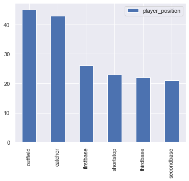

```python
dfpositionwhite = pd.DataFrame(white['player_position'].value_counts())
plot = dfpositionwhite.plot.bar(y='player_position',figsize=(6,5))
```

```python
white.describe()
```

|  | salary | team_payroll | years_played | games_played | career_at_bats | career_runs | career_hits | career_doubles | career_triples | career_homeruns | career_runs_batted_in | career_batting_average | career_walks | career_strike_outs | career_stolen_bases | career_fielding_percent | white_percent_in_city | black_percent_in_city | hispanic_percent_in_city |
| --- | --- | --- | --- | --- | --- | --- | --- | --- | --- | --- | --- | --- | --- | --- | --- | --- | --- | --- | --- |
| count | 1.800000e+02 | 1.800000e+02 | 180.000000 | 180.000000 | 180.000000 | 180.000000 | 180.000000 | 180.000000 | 180.000000 | 180.000000 | 180.000000 | 180.000000 | 180.000000 | 180.000000 | 180.000000 | 180.000000 | 180.000000 | 180.000000 | 180.000000 |
| mean | 1.237650e+06 | 3.123098e+07 | 6.338889 | 637.583333 | 2096.805556 | 271.377778 | 558.022222 | 104.900000 | 14.322222 | 53.916667 | 256.205556 | 252.838889 | 214.166667 | 327.238889 | 45.561111 | 977.411111 | 71.237360 | 15.794309 | 11.508165 |
| std | 1.248731e+06 | 8.114020e+06 | 3.839175 | 521.549088 | 1950.551098 | 284.803199 | 555.360882 | 106.196724 | 20.042596 | 69.278958 | 270.001401 | 28.727610 | 222.665380 | 322.590810 | 77.071987 | 20.327428 | 14.887374 | 13.310011 | 9.188896 |
| min | 1.090000e+05 | 8.854000e+06 | 1.000000 | 7.000000 | 14.000000 | 1.000000 | 2.000000 | 0.000000 | 0.000000 | 0.000000 | 2.000000 | 143.000000 | 0.000000 | 3.000000 | 0.000000 | 850.000000 | 20.296300 | 3.741786 | 0.540870 |
| 25% | 2.487500e+05 | 2.695897e+07 | 3.000000 | 229.250000 | 615.500000 | 71.000000 | 147.000000 | 26.750000 | 2.000000 | 8.000000 | 58.500000 | 237.000000 | 52.500000 | 100.000000 | 3.000000 | 968.750000 | 60.975630 | 7.986870 | 3.532760 |
| 50% | 6.625000e+05 | 3.413650e+07 | 6.000000 | 518.500000 | 1521.000000 | 179.500000 | 394.000000 | 75.500000 | 8.000000 | 29.000000 | 169.500000 | 254.000000 | 141.000000 | 228.000000 | 18.500000 | 983.000000 | 73.149640 | 13.303300 | 10.877800 |
| 75% | 2.112500e+06 | 3.736794e+07 | 9.000000 | 926.250000 | 2981.750000 | 384.750000 | 772.000000 | 145.500000 | 18.000000 | 69.250000 | 351.750000 | 269.250000 | 309.750000 | 458.250000 | 48.500000 | 990.000000 | 82.269067 | 17.528360 | 16.330650 |
| max | 5.359973e+06 | 4.286600e+07 | 20.000000 | 2729.000000 | 10554.000000 | 1570.000000 | 3025.000000 | 634.000000 | 134.000000 | 398.000000 | 1520.000000 | 338.000000 | 1057.000000 | 1891.000000 | 437.000000 | 1000.000000 | 94.696270 | 73.960030 | 31.037500 |

```python
df.groupby('race').median()
```

| race | salary | team_payroll | years_played | games_played | career_at_bats | career_runs | career_hits | career_doubles | career_triples | career_homeruns | career_runs_batted_in | career_batting_average | career_walks | career_strike_outs | career_stolen_bases | career_fielding_percent | white_percent_in_city | black_percent_in_city | hispanic_percent_in_city |
| --- | --- | --- | --- | --- | --- | --- | --- | --- | --- | --- | --- | --- | --- | --- | --- | --- | --- | --- | --- |
| black | 968333.5 | 35228168.0 | 6.0 | 583.5 | 1876.5 | 264.5 | 495.0 | 80.0 | 14.0 | 38.0 | 231.5 | 263.5 | 167.5 | 291.0 | 56.0 | 980.0 | 74.61965 | 14.45398 | 5.743671 |
| hispanic | 500000.0 | 30275667.0 | 4.0 | 410.5 | 1286.0 | 139.0 | 319.5 | 50.0 | 7.5 | 14.5 | 117.0 | 259.0 | 100.5 | 170.0 | 16.5 | 976.5 | 73.39629 | 14.45398 | 10.877800 |
| white | 662500.0 | 34136500.0 | 6.0 | 518.5 | 1521.0 | 179.5 | 394.0 | 75.5 | 8.0 | 29.0 | 169.5 | 254.0 | 141.0 | 228.0 | 18.5 | 983.0 | 74.61965 | 14.45398 | 10.877800 |

# 7.1. T-test on subsets of data

#### Lets test if the salary of the white players are significantly different from the salary of black players or not.

```python
white = df[df['race'] == "white"]
white_highhitters = white[(white['career_runs']>=400) & (white['career_runs']<=1500)]
white_highhitters.describe()
```

|  | salary | team_payroll | years_played | games_played | career_at_bats | career_runs | career_hits | career_doubles | career_triples | career_homeruns | career_runs_batted_in | career_batting_average | career_walks | career_strike_outs | career_stolen_bases | career_fielding_percent | white_percent_in_city | black_percent_in_city | hispanic_percent_in_city |
| --- | --- | --- | --- | --- | --- | --- | --- | --- | --- | --- | --- | --- | --- | --- | --- | --- | --- | --- | --- |
| count | 4.000000e+01 | 4.000000e+01 | 40.000000 | 40.000000 | 40.00000 | 40.000000 | 40.000000 | 40.000000 | 40.000000 | 40.000000 | 40.000000 | 40.000000 | 40.000000 | 40.000000 | 40.000000 | 40.000000 | 40.000000 | 40.000000 | 40.000000 |
| mean | 2.476374e+06 | 3.377487e+07 | 10.350000 | 1270.850000 | 4477.22500 | 641.125000 | 1217.675000 | 219.475000 | 33.600000 | 128.300000 | 563.425000 | 269.425000 | 492.425000 | 691.175000 | 122.075000 | 977.250000 | 73.550169 | 14.776696 | 10.662249 |
| std | 1.440554e+06 | 5.953509e+06 | 2.370221 | 319.737918 | 1379.16371 | 222.468573 | 433.719713 | 82.809942 | 20.321518 | 72.970032 | 214.463061 | 23.835857 | 183.324133 | 298.262136 | 118.461373 | 13.887367 | 10.428274 | 6.964877 | 9.671767 |
| min | 1.500000e+05 | 2.284083e+07 | 7.000000 | 831.000000 | 2873.00000 | 402.000000 | 693.000000 | 121.000000 | 5.000000 | 10.000000 | 240.000000 | 222.000000 | 188.000000 | 230.000000 | 6.000000 | 939.000000 | 51.496870 | 3.741786 | 0.575392 |
| 25% | 1.137500e+06 | 2.762823e+07 | 8.750000 | 992.500000 | 3281.25000 | 478.250000 | 875.000000 | 160.750000 | 18.750000 | 67.500000 | 399.000000 | 252.250000 | 368.250000 | 518.500000 | 36.750000 | 970.250000 | 67.668960 | 8.002376 | 2.887507 |
| 50% | 2.458334e+06 | 3.583150e+07 | 10.000000 | 1240.000000 | 4127.50000 | 559.000000 | 1101.000000 | 191.500000 | 29.000000 | 118.500000 | 513.500000 | 266.500000 | 459.500000 | 633.000000 | 76.500000 | 978.000000 | 74.619650 | 13.303300 | 7.742953 |
| 75% | 3.541667e+06 | 3.752178e+07 | 12.000000 | 1507.000000 | 5555.25000 | 748.750000 | 1471.250000 | 256.500000 | 41.750000 | 193.000000 | 703.000000 | 285.250000 | 581.750000 | 800.500000 | 209.000000 | 986.750000 | 78.783022 | 18.844230 | 16.330650 |
| max | 5.359973e+06 | 4.286600e+07 | 16.000000 | 1965.000000 | 7520.00000 | 1275.000000 | 2281.000000 | 422.000000 | 99.000000 | 273.000000 | 1014.000000 | 338.000000 | 1004.000000 | 1891.000000 | 437.000000 | 995.000000 | 94.696270 | 30.953870 | 31.037500 |

```python
test_white = white[(white['career_runs']>=400) & (white['career_runs']<=1500)]['salary']
test_white.mean()
```

```
2476374.325
```

```python
black = df[df['race'] == "black"]
black_highhitters = black[(black['career_runs']>=400) & (black['career_runs']<=1500)]
black_highhitters.describe()
```

|  | salary | team_payroll | years_played | games_played | career_at_bats | career_runs | career_hits | career_doubles | career_triples | career_homeruns | career_runs_batted_in | career_batting_average | career_walks | career_strike_outs | career_stolen_bases | career_fielding_percent | white_percent_in_city | black_percent_in_city | hispanic_percent_in_city |
| --- | --- | --- | --- | --- | --- | --- | --- | --- | --- | --- | --- | --- | --- | --- | --- | --- | --- | --- | --- |
| count | 3.600000e+01 | 3.600000e+01 | 36.000000 | 36.000000 | 36.000000 | 36.000000 | 36.000000 | 36.000000 | 36.000000 | 36.000000 | 36.000000 | 36.000000 | 36.000000 | 36.000000 | 36.000000 | 36.000000 | 36.000000 | 36.000000 | 36.000000 |
| mean | 3.089274e+06 | 3.536545e+07 | 10.527778 | 1317.111111 | 4802.527778 | 719.138889 | 1340.611111 | 229.611111 | 43.833333 | 136.111111 | 617.055556 | 277.222222 | 491.305556 | 722.805556 | 225.305556 | 977.277778 | 71.448159 | 16.523694 | 10.343339 |
| std | 1.654980e+06 | 5.828281e+06 | 3.325109 | 474.492136 | 1821.626957 | 292.952278 | 540.614427 | 92.273593 | 27.175094 | 95.147338 | 288.485993 | 17.151612 | 276.376536 | 260.884848 | 227.808920 | 10.154833 | 15.805655 | 15.396575 | 8.118586 |
| min | 2.500000e+05 | 2.298767e+07 | 5.000000 | 701.000000 | 2586.000000 | 402.000000 | 670.000000 | 19.000000 | 13.000000 | 17.000000 | 255.000000 | 254.000000 | 137.000000 | 291.000000 | 26.000000 | 952.000000 | 20.296300 | 3.741786 | 0.540870 |
| 25% | 1.650000e+06 | 3.413650e+07 | 8.000000 | 929.250000 | 3338.250000 | 499.750000 | 915.750000 | 159.250000 | 26.500000 | 69.500000 | 413.250000 | 262.750000 | 293.500000 | 537.500000 | 92.250000 | 971.750000 | 67.668960 | 7.986870 | 2.656150 |
| 50% | 3.404166e+06 | 3.672204e+07 | 10.000000 | 1253.500000 | 4221.500000 | 641.500000 | 1114.000000 | 218.500000 | 36.500000 | 109.500000 | 569.000000 | 275.500000 | 403.500000 | 730.500000 | 141.000000 | 979.000000 | 72.565670 | 12.257820 | 10.848805 |
| 75% | 4.125000e+06 | 3.855367e+07 | 13.000000 | 1490.250000 | 5712.000000 | 844.750000 | 1825.000000 | 276.500000 | 54.000000 | 178.250000 | 692.000000 | 286.750000 | 593.750000 | 892.000000 | 254.750000 | 984.250000 | 78.136865 | 18.844230 | 15.184672 |
| max | 6.200000e+06 | 4.286600e+07 | 17.000000 | 2444.000000 | 9124.000000 | 1472.000000 | 2646.000000 | 462.000000 | 142.000000 | 414.000000 | 1562.000000 | 327.000000 | 1286.000000 | 1313.000000 | 1042.000000 | 993.000000 | 94.696270 | 73.960030 | 31.037500 |

### 🔮 Hypothesis testing: Null and alternate hypothesis

We used 2 populations a)black players, b)white players; both these populations are farther filtered by their career runs. Both of the populations are in the same career runs range.

The two hypotheses for this two sample t-test are as follows:

1. H0: µ1 = µ2 (the two population means are equal)
2. HA: µ1 ≠ µ2 (the two population means are not equal)

```python
test_black = black[(black['career_runs']>=400) & (black['career_runs']<=1500)]['salary']
test_black.mean()
```

```
3089273.611111111
```

```python
stat, p = levene(test_black, test_white)
p
```

```
0.5747528285484527
```

We p value is > than .05 so we can assume **equal variance**.

```python
t_val, p_val = stats.ttest_ind(test_black,test_white, equal_var=True)
print(f"t-value: {t_val}, p_value:{p_val}")
```

```
t-value: 1.7260085055910541, p_value:0.08851920540864197
```

### ✨ Interpretation of the t-test:

Because the p-value of our test (0.08851920540864197) is greater than alpha = 0.05, we fail to reject the null hypothesis of the test. We do not have sufficient evidence to say that the mean salary between the two populations is different.

Within the same career runs range, black and white players salaries dont differ in any statistically significant manner. According to the data their is no apparent wage gap.

# 7.2. T-test on subsets of data

### Lets see if the outfielders are really better hitters or not.

### 🔮 Hypothesis testing: Null and alternate hypothesis

We used 2 populations a)Outfield players, b)Not outfield players; We will see if the means of career runs of these 2 subsets are significantly different or not.

The two hypotheses for this two sample t-test are as follows:

1. H0: µ1 = µ2 (the two population means are equal)
2. HA: µ1 ≠ µ2 (the two population means are not equal)

```python
heavyhitters_outfield = df[df['player_position'] == "outfield"]['career_runs']
heavyhitters_outfield.mean()
```

```
339.1029411764706
```

```python
heavyhitters_others = df[df['player_position'] != "outfield"]['career_runs']
heavyhitters_others.mean()
```

```
256.10185185185185
```

```python
t_val, p_val = stats.ttest_ind(heavyhitters_outfield, heavyhitters_others)
print(f't-value: {t_val},p-value: {p_val}')
```

```
t-value: 2.560197819591747,p-value: 0.01088046513395104
```

### ✨ Interpretation of the t-test:

Because the p-value of our test (0.01088046513395104) is lower than alpha = 0.05, we reject the null hypothesis of the test. We have sufficient evidence to say that the mean career runs of these two are statistically significant.

#### In simple words:

- Outfielders are definitely better run scorers than the others.

# 8. Linear regression and logarithmic transformation

```python
df2 = df.drop(['black_percent_in_city', 'white_percent_in_city', 'hispanic_percent_in_city','player_position','race','team_payroll'], axis=1)
```

[output not shown]

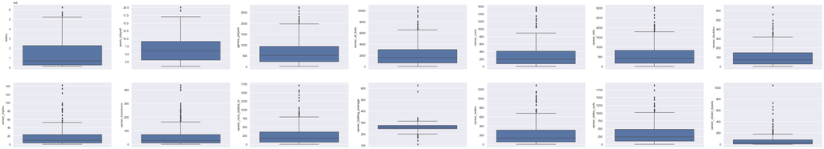

```python
fig, axs = plt.subplots(ncols=7, nrows=2, figsize=(55, 10))
index = 0
axs = axs.flatten()
for k,v in df2.items():
    sns.boxplot(y=k, data=df2, ax=axs[index])
    index += 1
plt.tight_layout(pad=0.4, w_pad=0.5, h_pad=5.0)
```

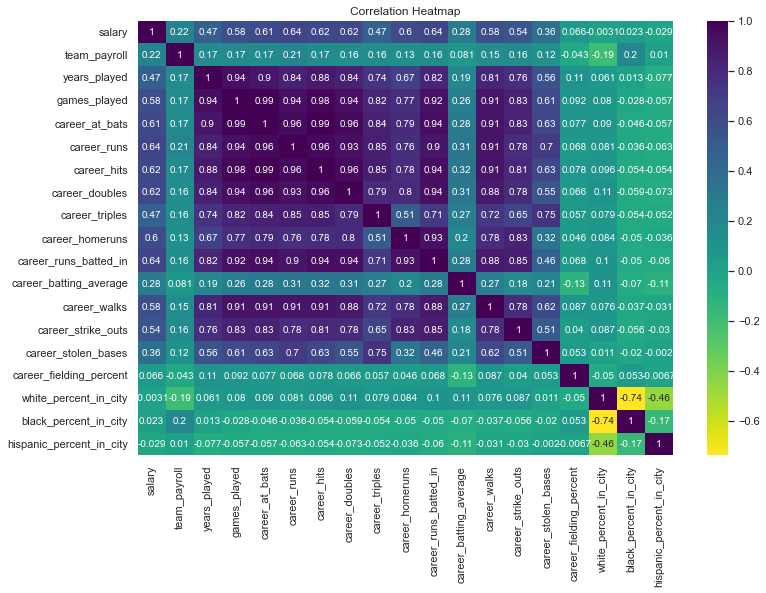

```python
plt.figure (figsize = (12, 8))
sns.heatmap (df.corr(), annot = True, cmap = 'viridis_r')
plt.title( "Correlation Heatmap")
```

### 🧮 Which variables to select for regression:

#### Variables : 'years_played','games_played', 'career_at_bats', 'career_runs', 'career_hits','career_doubles', 'career_triples', 'career_homeruns','career_runs_batted_in', 'career_walks', 'career_strike_outs', 'career_stolen_bases', 'career_fielding_percent'

```python
high_corr_features = ['years_played','games_played', 'career_at_bats', 'career_runs', 'career_hits',
            'career_doubles', 'career_triples', 'career_homeruns','career_runs_batted_in', 'career_walks',
            'career_strike_outs', 'career_stolen_bases', 'career_fielding_percent']
```

[output not shown]

[output cut: 115 more lines]

[output not shown]

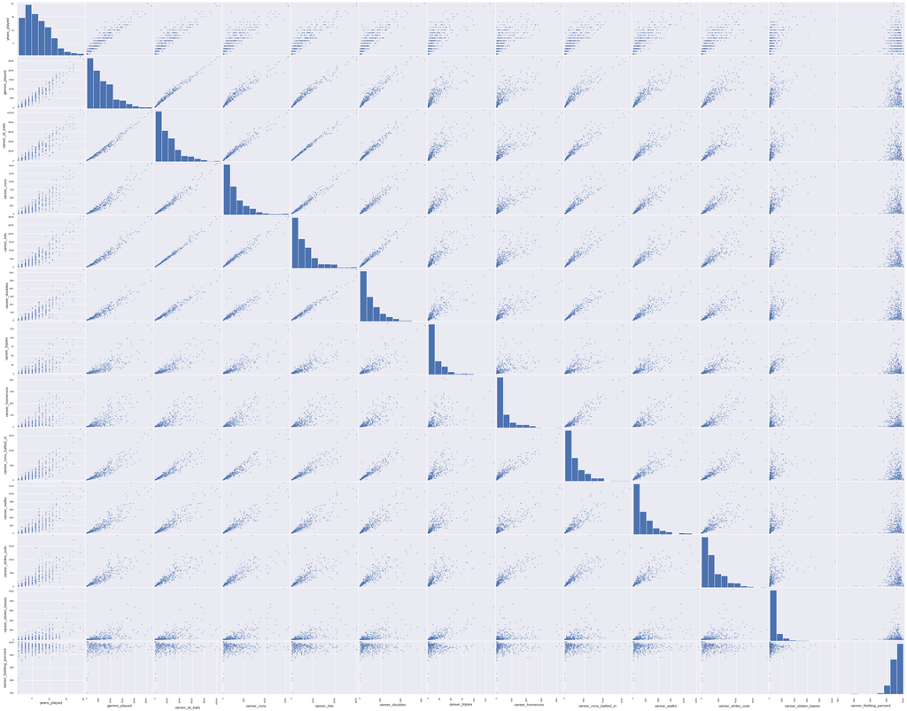

```python
pd.plotting.scatter_matrix(df[high_corr_features], figsize=(50,40))
```

```python
df.describe()
```

[output not shown]

### 🧑🏽‍🔬 Feature engineering:

1. Add 1 to all the columns that have a minimum value of 0.
2. Log transform all the data to prepare it for regression.

```python
df['career_doubles'] = df['career_doubles'] +1
df['career_triples'] = df['career_triples']+1
df['career_homeruns'] = df['career_homeruns']+1
df['career_walks'] = df['career_walks']+1
df['career_strike_outs'] = df['career_strike_outs']+1
df['career_stolen_bases'] = df['career_stolen_bases']+1
```

```python
df3log = pd.DataFrame()
df3log['years_played'] = np.log(df.years_played)
df3log['games_played'] = np.log(df.games_played)
df3log['career_at_bats'] = np.log(df.career_at_bats)
df3log['career_runs'] = np.log(df.career_runs)
df3log['career_hits'] = np.log(df.career_hits)
df3log['career_doubles'] = np.log(df.career_doubles)
df3log['career_triples'] = np.log(df.career_triples)
df3log['career_homeruns'] = np.log(df.career_homeruns)
df3log['career_runs_batted_in'] = np.log(df.career_runs_batted_in)
df3log['career_walks'] = np.log(df.career_walks)
df3log['career_strike_outs'] = np.log(df.career_strike_outs)
df3log['career_stolen_bases'] = np.log(df.career_stolen_bases)
df3log['career_fielding_percent'] = np.log(df.career_fielding_percent)
df3log['race'] = df.race
df3log['position'] = df.player_position
df3log['salary'] = np.log(df.salary)
```

```python
new_df3log = pd.get_dummies(df3log, columns=['race', 'position'], drop_first=True)
new_df3log.head(5)
```

|  | years_played | games_played | career_at_bats | career_runs | career_hits | career_doubles | career_triples | career_homeruns | career_runs_batted_in | career_walks | career_strike_outs | career_stolen_bases | career_fielding_percent | salary | race_hispanic | race_white | position_firstbase | position_outfield | position_secondbase | position_shortstop | position_thirdbase |
| --- | --- | --- | --- | --- | --- | --- | --- | --- | --- | --- | --- | --- | --- | --- | --- | --- | --- | --- | --- | --- | --- |
| 0 | 2.079442 | 6.822197 | 8.111628 | 6.008813 | 6.760415 | 5.056246 | 3.663562 | 4.304065 | 5.834811 | 4.927254 | 6.368187 | 4.897840 | 6.875232 | 15.031906 | 0 | 0 | 0 | 0 | 0 | 1 | 0 |
| 1 | 1.609438 | 6.621406 | 7.939872 | 5.913503 | 6.733402 | 5.003946 | 2.944439 | 3.850148 | 5.872118 | 5.834811 | 5.433722 | 3.737670 | 6.901737 | 14.946913 | 0 | 1 | 1 | 0 | 0 | 0 | 0 |
| 2 | 2.079442 | 6.962243 | 8.112827 | 6.003887 | 6.704414 | 4.969813 | 2.944439 | 4.682131 | 6.042633 | 5.726848 | 6.483107 | 2.772589 | 6.878326 | 14.880221 | 0 | 1 | 0 | 0 | 0 | 0 | 1 |
| 3 | 2.484907 | 7.086738 | 8.189522 | 6.079933 | 6.833032 | 2.995732 | 2.833213 | 4.828314 | 6.293419 | 5.758902 | 6.587550 | 3.496508 | 6.884487 | 14.316286 | 0 | 0 | 0 | 1 | 0 | 0 | 0 |
| 4 | 2.833213 | 7.616776 | 8.921191 | 7.035269 | 7.670895 | 5.602119 | 4.962845 | 3.713572 | 6.352629 | 6.033086 | 7.002156 | 6.493754 | 6.894670 | 13.458836 | 0 | 0 | 0 | 1 | 0 | 0 | 0 |

```python
model = sm.OLS.from_formula('salary ~ career_runs + career_homeruns ', data=new_df3log).fit()
```

```python
model.summary()
```

OLS Regression Results

| Dep. Variable: | salary | R-squared: | 0.632 |
| --- | --- | --- | --- |
| Model: | OLS | Adj. R-squared: | 0.630 |
| Method: | Least Squares | F-statistic: | 300.1 |
| Date: | Wed, 30 Nov 2022 | Prob (F-statistic): | 1.50e-76 |
| Time: | 17:15:30 | Log-Likelihood: | -380.68 |
| No. Observations: | 352 | AIC: | 767.4 |
| Df Residuals: | 349 | BIC: | 778.9 |
| Df Model: | 2 |  |  |
| Covariance Type: | nonrobust |  |  |

|  | coef | std err | t | P>\|t\| | [0.025 | 0.975] |
| --- | --- | --- | --- | --- | --- | --- |
| Intercept | 10.6262 | 0.146 | 73.012 | 0.000 | 10.340 | 10.912 |
| career_runs | 0.4235 | 0.047 | 8.983 | 0.000 | 0.331 | 0.516 |
| career_homeruns | 0.2403 | 0.046 | 5.243 | 0.000 | 0.150 | 0.330 |

| Omnibus: | 4.143 | Durbin-Watson: | 1.105 |
| --- | --- | --- | --- |
| Prob(Omnibus): | 0.126 | Jarque-Bera (JB): | 5.076 |
| Skew: | 0.054 | Prob(JB): | 0.0790 |
| Kurtosis: | 3.578 | Cond. No. | 24.9 |

Notes:  
[1] Standard Errors assume that the covariance matrix of the errors is correctly specified.

```python
high_corr_features = ['career_runs',  'career_homeruns']
df[high_corr_features].corr()
```

|  | career_runs | career_homeruns |
| --- | --- | --- |
| career_runs | 1.000000 | 0.756055 |
| career_homeruns | 0.756055 | 1.000000 |

## 🔬 Interpretation of regression:

Salary, (y) = 10.6262 + 0.4235(career_runs) + 0.2403(career_homeruns)

The equation values are log transformed.

If the career runs increase by 1 then the salary increases by 0.4235(units log transformed), if career_homeruns increases by 1 unit then salary increases by 0.2403 units.